# EasyVisa Project

## Context:

Business communities in the United States are facing high demand for human resources, but one of the constant challenges is identifying and attracting the right talent, which is perhaps the most important element in remaining competitive. Companies in the United States look for hard-working, talented, and qualified individuals both locally as well as abroad.

The Immigration and Nationality Act (INA) of the US permits foreign workers to come to the United States to work on either a temporary or permanent basis. The act also protects US workers against adverse impacts on their wages or working conditions by ensuring US employers' compliance with statutory requirements when they hire foreign workers to fill workforce shortages. The immigration programs are administered by the Office of Foreign Labor Certification (OFLC).

OFLC processes job certification applications for employers seeking to bring foreign workers into the United States and grants certifications in those cases where employers can demonstrate that there are not sufficient US workers available to perform the work at wages that meet or exceed the wage paid for the occupation in the area of intended employment.

## Objective:

In FY 2016, the OFLC processed 775,979 employer applications for 1,699,957 positions for temporary and permanent labor certifications. This was a nine percent increase in the overall number of processed applications from the previous year. The process of reviewing every case is becoming a tedious task as the number of applicants is increasing every year.

The increasing number of applicants every year calls for a Machine Learning based solution that can help in shortlisting the candidates having higher chances of VISA approval. OFLC has hired your firm EasyVisa for data-driven solutions. You as a data scientist have to analyze the data provided and, with the help of a classification model:

- Facilitate the process of visa approvals.
- Recommend a suitable profile for the applicants for whom the visa should be certified or denied based on the drivers that significantly influence the case status.

## Data Description

The data contains the different attributes of the employee and the employer. The detailed data dictionary is given below.

- case_id: ID of each visa application
- continent: Information of continent the employee
- education_of_employee: Information of education of the employee
- has_job_experience: Does the employee has any job experience? Y= Yes; N = No
- requires_job_training: Does the employee require any job training? Y = Yes; N = No
- no_of_employees: Number of employees in the employer's company
- yr_of_estab: Year in which the employer's company was established
- region_of_employment: Information of foreign worker's intended region of employment in the US.
- prevailing_wage: Average wage paid to similarly employed workers in a specific occupation in the area of intended employment. The purpose of the prevailing wage is to ensure that the foreign worker is not underpaid compared to other workers offering the same or similar service in the same area of employment.
- unit_of_wage: Unit of prevailing wage. Values include Hourly, Weekly, Monthly, and Yearly.
- full_time_position: Is the position of work full-time? Y = Full Time Position; N = Part Time Position
- case_status: Flag indicating if the Visa was certified or denied

## Problem definition

Processing an ever-increasing number of employer applications for temporary and permanent labor certifications presents a major challenge for the Office of Foreign Labor Certification, which is addressed by the EasyVisa Project. The present 775,979 applications for 1,699,957 posts in FY 2016 alone are progressively making the human screening process unsustainable and wasteful due to year-over-year volume rise.

The main issues are:

*Time and Resource Use*: Manually evaluating applications to see whether they adhere to established legal and labor market norms takes a significant amount of time and resources.

*Complexity of Decision-Making*: The availability of US workers, pay conditions, and occupation-specific standards are among the aspects to be considered in the visa certification process, which makes decision-making difficult.

*Vulnerability to Error*: The workload increase might trigger inconsistencies and errors in decisions taken.

A Machine Learning-based solution is required, that can help:

*Facilitate the process of visa approvals*.

*Recommend a suitable profile for the applicants for whom the visa should be certified or denied based on the drivers that significantly influence the case status*.

## Importing necessary libraries and data

```python
# Installing the libraries with the specified version.
!pip install numpy==1.25.2 pandas==1.5.3 scikit-learn==1.2.2 matplotlib==3.7.1 seaborn==0.13.1 xgboost==2.0.3
```

**Note**: *After running the above cell, kindly restart the notebook kernel and run all cells sequentially from the start again.*

```python
import warnings

warnings.filterwarnings("ignore")

from statsmodels.tools.sm_exceptions import ConvergenceWarning
warnings.simplefilter("ignore", ConvergenceWarning)

# Libraries to help with reading and manipulating data
import numpy as np
import pandas as pd

# Library to split data
from sklearn.model_selection import train_test_split

# libaries to help with data visualization
import matplotlib.pyplot as plt
import seaborn as sns

# Removes the limit for the number of displayed columns
pd.set_option("display.max_columns", None)
# Sets the limit for the number of displayed rows
pd.set_option("display.max_rows", 100)


# Libraries different ensemble classifiers
from sklearn.ensemble import (
    BaggingClassifier,
    RandomForestClassifier,
    AdaBoostClassifier,
    GradientBoostingClassifier,
    StackingClassifier,
)

from xgboost import XGBClassifier
from sklearn.tree import DecisionTreeClassifier

# Libraries to get different metric scores
from sklearn import metrics
from sklearn.metrics import (
    confusion_matrix,
    accuracy_score,
    precision_score,
    recall_score,
    f1_score,
)

# To tune different models
from sklearn.model_selection import GridSearchCV
```

## Importing Dataset

```python
# uncomment and run the following lines for Google Colab
# from google.colab import drive
# drive.mount('/content/drive')
```

```python
# Code to let colab access my google drive
from google.colab import drive
drive.mount('/content/drive')
```

```python
# Code to read dataset
data = pd.read_csv('/content/drive/My Drive/EasyVisa.csv')
```

```python
# copying data to another variable to avoid any changes to original data
data = data.copy()
```

## Data Overview

- Observations
- Sanity checks
- *Observations* to check if data has been uploaded properly or not. Here, I check the first five rows and the last 5 rows of the dataset
- *Sanity* checks to get information about the number of rows and columns in the dataset, find out the data types of the columns to ensure that data is stored in the preferred format and the value of each property is as expected, check the statistical summary of the dataset to get an overview of the numerical columns of the data, check for duplicate values, and missing values.

### View the first and last 5 rows of the dataset

```python
# Code to view the first 5 rows of the dataset
data.head()
```

|  | case_id | continent | education_of_employee | has_job_experience | requires_job_training | no_of_employees | yr_of_estab | region_of_employment | prevailing_wage | unit_of_wage | full_time_position | case_status |
| --- | --- | --- | --- | --- | --- | --- | --- | --- | --- | --- | --- | --- |
| 0 | EZYV01 | Asia | High School | N | N | 14513 | 2007 | West | 592.2029 | Hour | Y | Denied |
| 1 | EZYV02 | Asia | Master's | Y | N | 2412 | 2002 | Northeast | 83425.6500 | Year | Y | Certified |
| 2 | EZYV03 | Asia | Bachelor's | N | Y | 44444 | 2008 | West | 122996.8600 | Year | Y | Denied |
| 3 | EZYV04 | Asia | Bachelor's | N | N | 98 | 1897 | West | 83434.0300 | Year | Y | Denied |
| 4 | EZYV05 | Africa | Master's | Y | N | 1082 | 2005 | South | 149907.3900 | Year | Y | Certified |

```python
# Code to view the last 5 rows of the dataset
data.tail()
```

|  | case_id | continent | education_of_employee | has_job_experience | requires_job_training | no_of_employees | yr_of_estab | region_of_employment | prevailing_wage | unit_of_wage | full_time_position | case_status |
| --- | --- | --- | --- | --- | --- | --- | --- | --- | --- | --- | --- | --- |
| 25475 | EZYV25476 | Asia | Bachelor's | Y | Y | 2601 | 2008 | South | 77092.57 | Year | Y | Certified |
| 25476 | EZYV25477 | Asia | High School | Y | N | 3274 | 2006 | Northeast | 279174.79 | Year | Y | Certified |
| 25477 | EZYV25478 | Asia | Master's | Y | N | 1121 | 1910 | South | 146298.85 | Year | N | Certified |
| 25478 | EZYV25479 | Asia | Master's | Y | Y | 1918 | 1887 | West | 86154.77 | Year | Y | Certified |
| 25479 | EZYV25480 | Asia | Bachelor's | Y | N | 3195 | 1960 | Midwest | 70876.91 | Year | Y | Certified |

*Observations*

The dataset has been uploaded properly, clearly identifying the columns (variables) and the rows (observations) in the dataset. We can proceed to check the shape of the data to know exactly how many columns and rows are there.

```python
# Code to check the shape of the dataset
data.shape
print('There are', data.shape[0],'rows and', data.shape[1],'columns')
```

```
There are 25480 rows and 12 columns
```

*Observations*

The dataset has 25480 rows (observations) and 12 columns (variables).

We can proceed to check the datatypes of the different columns in the dataset.

```python
# Code to determine datatypes of different columns in the dataset
info = data.info()
print(info)
```

```
<class 'pandas.core.frame.DataFrame'>
RangeIndex: 25480 entries, 0 to 25479
Data columns (total 12 columns):
 #   Column                 Non-Null Count  Dtype
---  ------                 --------------  -----
 0   case_id                25480 non-null  object
 1   continent              25480 non-null  object
 2   education_of_employee  25480 non-null  object
 3   has_job_experience     25480 non-null  object
 4   requires_job_training  25480 non-null  object
 5   no_of_employees        25480 non-null  int64
 6   yr_of_estab            25480 non-null  int64
 7   region_of_employment   25480 non-null  object
 8   prevailing_wage        25480 non-null  float64
 9   unit_of_wage           25480 non-null  object
 10  full_time_position     25480 non-null  object
 11  case_status            25480 non-null  object
dtypes: float64(1), int64(2), object(9)
memory usage: 2.3+ MB
None
```

*Observations*

Of the 12 columns in the dataset, we have 1 float, 2 integers, and 9 objects. Memory usage is 2.3+ MB.

```python
# Code to check the statistical summary of dataset
data.describe().T
```

|  | count | mean | std | min | 25% | 50% | 75% | max |
| --- | --- | --- | --- | --- | --- | --- | --- | --- |
| no_of_employees | 25480.0 | 5667.043210 | 22877.928848 | -26.0000 | 1022.00 | 2109.00 | 3504.0000 | 602069.00 |
| yr_of_estab | 25480.0 | 1979.409929 | 42.366929 | 1800.0000 | 1976.00 | 1997.00 | 2005.0000 | 2016.00 |
| prevailing_wage | 25480.0 | 74455.814592 | 52815.942327 | 2.1367 | 34015.48 | 70308.21 | 107735.5125 | 319210.27 |

*Observations*

- Minimum number of employees shows a negative 26. It is not possible to have negative values in number of employees. This needs to be fixed.

#### Fixing the negative values in number of employees columns

```python
data.loc[data['no_of_employees'] < 0].shape ## Complete the code to check negative values in the employee column
```

```
(33, 12)
```

```python
# taking the absolute values for number of employees
data["no_of_employees"] = abs(data["no_of_employees"])
```

```python
# Code to check the statistical summary of dataset to see if the negative values in the employee column has been addressed.
data.describe().T
```

|  | count | mean | std | min | 25% | 50% | 75% | max |
| --- | --- | --- | --- | --- | --- | --- | --- | --- |
| no_of_employees | 25480.0 | 5667.089207 | 22877.917453 | 11.0000 | 1022.00 | 2109.00 | 3504.0000 | 602069.00 |
| yr_of_estab | 25480.0 | 1979.409929 | 42.366929 | 1800.0000 | 1976.00 | 1997.00 | 2005.0000 | 2016.00 |
| prevailing_wage | 25480.0 | 74455.814592 | 52815.942327 | 2.1367 | 34015.48 | 70308.21 | 107735.5125 | 319210.27 |

#### Let's check the count of each unique category in each of the categorical variables

```python
# Making a list of all categorical variables
cat_col = list(data.select_dtypes("object").columns)

# Printing number of count of each unique value in each column
for column in cat_col:
    print(data[column].value_counts())
    print("-" * 50)
```

```
EZYV01       1
EZYV16995    1
EZYV16993    1
EZYV16992    1
EZYV16991    1
            ..
EZYV8492     1
EZYV8491     1
EZYV8490     1
EZYV8489     1
EZYV25480    1
Name: case_id, Length: 25480, dtype: int64
--------------------------------------------------
Asia             16861
Europe            3732
North America     3292
South America      852
Africa             551
Oceania            192
Name: continent, dtype: int64
--------------------------------------------------
Bachelor's     10234
Master's        9634
High School     3420
Doctorate       2192
Name: education_of_employee, dtype: int64
--------------------------------------------------
Y    14802
N    10678
Name: has_job_experience, dtype: int64
--------------------------------------------------
N    22525
Y     2955
Name: requires_job_training, dtype: int64
--------------------------------------------------
Northeast    7195
South        7017
West         6586
Midwest      4307
Island        375
Name: region_of_employment, dtype: int64
--------------------------------------------------
Year     22962
Hour      2157
Week       272
Month       89
Name: unit_of_wage, dtype: int64
--------------------------------------------------
Y    22773
N     2707
Name: full_time_position, dtype: int64
--------------------------------------------------
Certified    17018
Denied        8462
Name: case_status, dtype: int64
--------------------------------------------------
```

*Observations*

```python
data["case_id"].nunique() ## Complete the code to check unique values in the mentioned column
```

```
25480
```

```python
data.drop(["case_id"], axis=1, inplace=True) ## Complete the code to drop 'case_id' column from the data
```

```python
# Code to view the first 5 rows of the dataset to show that 'case_id' has been dropped
data.head()
```

|  | continent | education_of_employee | has_job_experience | requires_job_training | no_of_employees | yr_of_estab | region_of_employment | prevailing_wage | unit_of_wage | full_time_position | case_status |
| --- | --- | --- | --- | --- | --- | --- | --- | --- | --- | --- | --- |
| 0 | Asia | High School | N | N | 14513 | 2007 | West | 592.2029 | Hour | Y | Denied |
| 1 | Asia | Master's | Y | N | 2412 | 2002 | Northeast | 83425.6500 | Year | Y | Certified |
| 2 | Asia | Bachelor's | N | Y | 44444 | 2008 | West | 122996.8600 | Year | Y | Denied |
| 3 | Asia | Bachelor's | N | N | 98 | 1897 | West | 83434.0300 | Year | Y | Denied |
| 4 | Africa | Master's | Y | N | 1082 | 2005 | South | 149907.3900 | Year | Y | Certified |

*Observations*

case_id has been dropped.

```python
# Code to check for duplicates
data.duplicated().sum()
```

```
0
```

```python
# Code to confirm that there are no duplicates
data[data.duplicated()]
```

|  | continent | education_of_employee | has_job_experience | requires_job_training | no_of_employees | yr_of_estab | region_of_employment | prevailing_wage | unit_of_wage | full_time_position | case_status |
| --- | --- | --- | --- | --- | --- | --- | --- | --- | --- | --- | --- |

*Observations*

There are no duplicates in the dataset.

## Exploratory Data Analysis (EDA)

- EDA is an important part of any project involving data.
- It is important to investigate and understand the data better before building a model with it.
- A few questions have been mentioned below which will help you approach the analysis in the right manner and generate insights from the data.
- A thorough analysis of the data, in addition to the questions mentioned below, should be done.

**Leading Questions**:

1. Those with higher education may want to travel abroad for a well-paid job. Does education play a role in Visa certification?
2. How does the visa status vary across different continents?
3. Experienced professionals might look abroad for opportunities to improve their lifestyles and career development. Does work experience influence visa status?
4. In the United States, employees are paid at different intervals. Which pay unit is most likely to be certified for a visa?
5. The US government has established a prevailing wage to protect local talent and foreign workers. How does the visa status change with the prevailing wage?

### Univariate Analysis

This will be done for the following variables: continent, education_of_employees,has_job_experience, requires_job_training, no_of_employees, region_of_employment, prevailing_wage, unit_of_wage, full_time_position, case_status

```python
def histogram_boxplot(data, feature, figsize=(15, 10), kde=False, bins=None):
    """
    Boxplot and histogram combined

    data: dataframe
    feature: dataframe column
    figsize: size of figure (default (15,10))
    kde: whether to show the density curve (default False)
    bins: number of bins for histogram (default None)
    """
    f2, (ax_box2, ax_hist2) = plt.subplots(
        nrows=2,  # Number of rows of the subplot grid= 2
        sharex=True,  # x-axis will be shared among all subplots
        gridspec_kw={"height_ratios": (0.25, 0.75)},
        figsize=figsize,
    )  # creating the 2 subplots
    sns.boxplot(
        data=data, x=feature, ax=ax_box2, showmeans=True, color="violet"
    )  # boxplot will be created and a triangle will indicate the mean value of the column
    sns.histplot(
        data=data, x=feature, kde=kde, ax=ax_hist2, bins=bins
    ) if bins else sns.histplot(
        data=data, x=feature, kde=kde, ax=ax_hist2
    )  # For histogram
    ax_hist2.axvline(
        data[feature].mean(), color="green", linestyle="--"
    )  # Add mean to the histogram
    ax_hist2.axvline(
        data[feature].median(), color="black", linestyle="-"
    )  # Add median to the histogram
```

```python
def labeled_barplot(data, feature, perc=False, n=None):
    """
    Barplot with percentage at the top

    data: dataframe
    feature: dataframe column
    perc: whether to display percentages instead of counts (default is False)
    n: displays the top n category levels (default is None, i.e., display all levels)
    """

    total = len(data[feature])  # length of the column
    count = data[feature].value_counts().sort_values(ascending=False)  # counting the values and arranging in descending order
    if n is not None:
        count = count.head(n)  # takes the top n values of the counts variable
    perc_count = (count / total) * 100  # calculating the percentage
    index = count.index  # gets the index of the count variable

    plt.figure(figsize=(15, 5))
    sns.countplot(
        data=data,
        x=feature,
        order=index,
    )
    plt.xticks(rotation=90)  # Rotating the x-ticks by 90 degrees

    # Adding the percentage at the top
    for i in range(len(index)):
        value = perc_count[i] if perc else count[i]  # Using perc_count if perc is True, else count
        label = f"{round(value, 2)}%" if perc else f"{value}"  # Rounding the percentage to 2 decimal places
        plt.text(
            i,
            value,
            label,
            ha="center",
            va="bottom",
            fontweight="bold",
        )

    plt.show()
```

#### Observations on continent

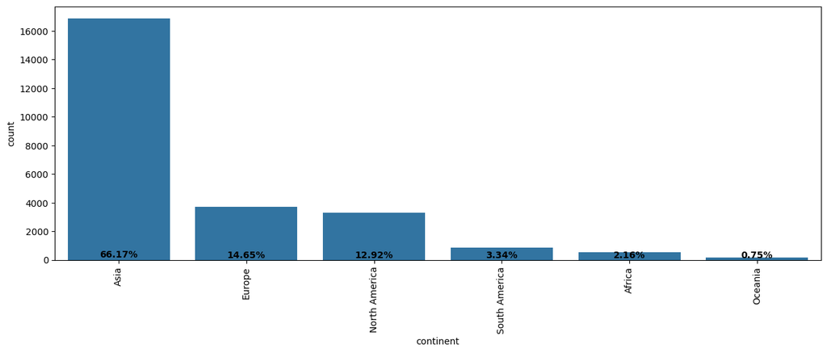

```python
labeled_barplot(data, "continent", perc=True)
```

*Observation*

Asia has the highest number of applicants, followed by Europe, then North America, then South America, Africa, and Oceania.

### Observations on education of employee

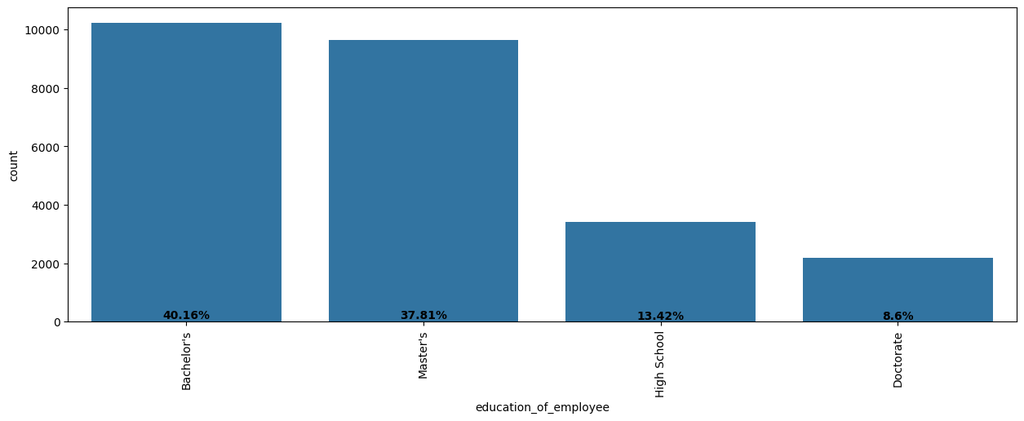

```python
labeled_barplot(data, "education_of_employee", perc=True)  ## Complete the code to create labeled_barplot for education of employee
```

*Observations*

40.1% of the visa applicants have a Bachelor's degree. 37.8 % have a Master's. Those with high school represent 13.4%. Doctorate represents 8.6%. Doctorate represents the lowest number, whereas Bachelor's represent the highest.

### Observations on job experience

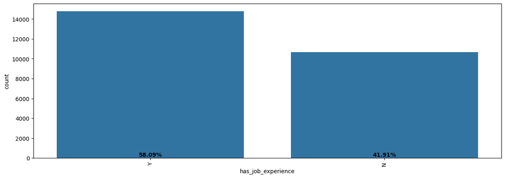

```python
labeled_barplot(data, "has_job_experience", perc=True)  ## Complete the code to create labeled_barplot for job experience
```

*Observations*

Among the visa applicants of 25480, 58.09% have job experience. 41.91% do not have job experience. We need to investigate whether job experience has an effect on visa approval or denial.

### Observations on job training

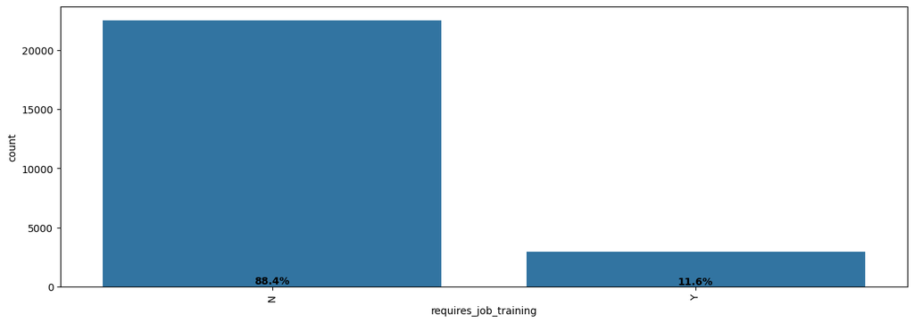

```python
labeled_barplot(data, 'requires_job_training', perc=True)  ## Complete the code to create labeled_barplot for requires_job_training
```

*Observations*

88.4% of the applicants require no training. This represents 22,525. 11.6% require training. This represents 2,955.